# 6 - Loops und Funktionen

Benedict Witzenberger  
18. April 2019

### Recap

Es gibt wieder eine Übung zu allem, was wir gestern gelernt haben:

### Was wir heute vorhaben

### R

Loops in R

eigene Funktionen in R

Wo bekommen wir Hilfe?

Ausblick: Visualisierung mit Base R

### Projekte

Wie machen wir Datenjournalismus

Unser eigenes Projekt

### Loops (Schleifen) in R

**Warum brauchen wir Loops?**

Wir wiederholen die gleichen Arbeitsschritte immer und immer wieder…

… bis ein bestimmter Zustand eingetreten ist:

- for-Loops: “bis” ein Zustand eingetreten ist
- while-Loops: “während” ein Zustand eingetreten ist (ähnlich zum repeat-Loop)

Diese Wiederholungen werden im Entwicklerslang: “Iteration” genannt

### Wie Loops aussehen

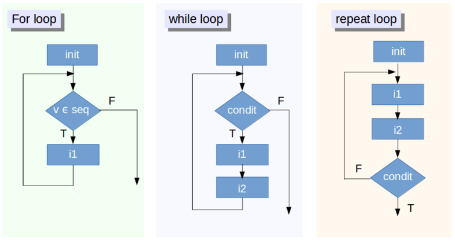

### For-Loop I

```r
iterator <- c(1:10)

for (i in iterator) {
  print(i)
}
```

```
[1] 1
[1] 2
[1] 3
[1] 4
[1] 5
[1] 6
[1] 7
[1] 8
[1] 9
[1] 10
```

Was ist `i`?

### For-Loop II

```r
result <- vector()

input_vector <- c(1:10)

for(i in seq_along(input_vector)) {
  result[i] <- input_vector[i] * input_vector[i]
  print(paste("i:", i, "; Result:", result[i]))
}
```

```
[1] "i: 1 ; Result: 1"
[1] "i: 2 ; Result: 4"
[1] "i: 3 ; Result: 9"
[1] "i: 4 ; Result: 16"
[1] "i: 5 ; Result: 25"
[1] "i: 6 ; Result: 36"
[1] "i: 7 ; Result: 49"
[1] "i: 8 ; Result: 64"
[1] "i: 9 ; Result: 81"
[1] "i: 10 ; Result: 100"
```

### Naming Convention in For-Loops

```
for (i in seq-along(vector1)) {
  for (j in seq_along(vector2)) {
    for (k in seq_along(vector3)) {
      do_something()
    }
  }
}
```

### Denkaufgabe: For-Loops für Matrix

Erstellt mit einem Loop eine Matrix, in der der Inhalt jedes Feldes das Produkt seiner Indizes ist.

```
mymat <- matrix(nrow=30, ncol=30)

# For each row and for each column, assign values based on position: product of two indexes
for(i in 1:dim(mymat)[]) {
  for(j in 1:dim(mymat)[]) {
    mymat[i,j] =
  }
}
```

Tipp: Ihr müsst in der Funktion drei Sachen eintragen

### Lösung: For-Loops für Matrix

```r
mymat <- matrix(nrow=30, ncol=30)

for(i in 1:dim(mymat)[1]) {
  for(j in 1:dim(mymat)[2]) {
    mymat[i,j] = i*j
  }
}

mymat[1:10, 1:10]
```

```
      [,1] [,2] [,3] [,4] [,5] [,6] [,7] [,8] [,9] [,10]
 [1,]    1    2    3    4    5    6    7    8    9    10
 [2,]    2    4    6    8   10   12   14   16   18    20
 [3,]    3    6    9   12   15   18   21   24   27    30
 [4,]    4    8   12   16   20   24   28   32   36    40
 [5,]    5   10   15   20   25   30   35   40   45    50
 [6,]    6   12   18   24   30   36   42   48   54    60
 [7,]    7   14   21   28   35   42   49   56   63    70
 [8,]    8   16   24   32   40   48   56   64   72    80
 [9,]    9   18   27   36   45   54   63   72   81    90
[10,]   10   20   30   40   50   60   70   80   90   100
```

### Best Practises bei For-Loops

Füllt eine Ergebnisvariable nicht IM Loop. Sie muss dann von Loop-Durchgang zu Loop-Durchgang kopiert werden, das macht den Code langsam.

Besser: Erstellt eine Ergebnisvariable (zum Beispiel Liste, Vektor oder Dataframe) VOR dem Loop. Und befüllt mit [i] nur die entsprechenden Bereiche im Loop.

Nicht:

```
for (i in seq_along(vector)) {
  loop_-_result <- compute_something()
  result_variable <- c(result_variable, loop_result)
}
```

Besser:

```
result_variable <- vector(length = length(input_vector))

for (i in seq_along(input_vector)) {
  loop_result <- compute_something()
  result_variable[i] <- loop_result
}
```

### Bei Dataframes

```
result_list <- list()

for (i in seq_along(input_vector)) {
  loop_result_df <- compute_something()
  result_list[[i]] <- loop_result_df
}

dplyr::bind_rows(result_list)
```

dplyr lernt ihr im nächsten Blockkurs genauer kennen.

### For-Loops gibt es in vielen Sprachen

Java:

```
// Prints the numbers 0 to 99 (and not 100), each followed by a space.
for (int i=0; i<100; i++)
{
    System.out.print(i);
    System.out.print(' ');
}
System.out.println();
```

Python:

```
for item in some_iterable_object:
    do_something()
```

### Wann brauchen wir For-Loops in R?

- Viele Daten einlesen und bearbeiten
- Viele Webseiten scrapen

Eher nicht bei:

- Mehrere Variablen eines Dataframes verändern
- Mehrere Rechnungen mit Vektoren anstellen

### Vorsicht bei For-Loops I

```r
a <- c(1:10)
b <- c(1:10)

res <- numeric(length = length(a))
for (i in seq_along(a)) {
  res[i] <- a[i] + b[i]
}
res
```

```
 [1]  2  4  6  8 10 12 14 16 18 20
```

Was macht die For-Schleife?

### Vorsicht bei For-Loops II

Für viele Vektoroperationen gibt es einfacherere - und schnellere Alternativen, als eine For-Schleife:

Hier, eine einfache Summe.

```r
res2 <- a + b

all.equal(res, res2) # testet, ob die Variablen gleich sind
```

```
[1] TRUE
```

### Apply-Familie in R

Loops, die ihr über Vektoren laufen lassen wollt, können oft mit Apply kombiniert werden. Diese Funktionen sind deutlich schneller, als For-Loops (wird daher erst bei großen Datensätzen interessant)

- Apply: `apply(X, MARGIN, FUN, ...)`, MARGIN sind die Zeilen und Spalten einer Matrix (oder eines Dataframes). Es geht auch `MARGIN = c(1,2)`. FUN kann jede beliebige (auch selbst geschriebene Funktion sein).
- Lapply: Gibt die Ergebnisse der Apply-Berechnung als Liste zurück. Jedes Ergebnis ist ein Element der Liste.
- Sapply: Funktioniert wie Lapply, versucht aber, das Ergebnis als Vektor oder Matrix auszugeben.
- Vapply: Hier gibt der Nutzer vorher ein, welche Klasse das Ergebnis haben soll, z.B. `VUN.VALUE = character(1)`

### Apply bei einer Matrix I

```r
matrix_x <- cbind(x1 = 3, x2 = c(4:1, 2:5))

dimnames(matrix_x)[[1]] <- letters[1:8]
matrix_x
```

```
  x1 x2
a  3  4
b  3  3
c  3  2
d  3  1
e  3  2
f  3  3
g  3  4
h  3  5
```

```r
apply(matrix_x, 2, mean, trim = .2)
```

```
x1 x2
 3  3
```

### Apply bei einer Matrix II

```r
col.sums <- apply(matrix_x, 2, sum)
row.sums <- apply(matrix_x, 1, sum)
rbind(cbind(matrix_x, Rtot = row.sums), Ctot = c(col.sums, sum(col.sums)))
```

```
     x1 x2 Rtot
a     3  4    7
b     3  3    6
c     3  2    5
d     3  1    4
e     3  2    5
f     3  3    6
g     3  4    7
h     3  5    8
Ctot 24 24   48
```

### Lapply, Sapply

```r
x <- list(a = 1:10, beta = exp(-3:3), logic = c(TRUE,FALSE,FALSE,TRUE))

lapply(x, quantile)
```

```
$a
   0%   25%   50%   75%  100%
 1.00  3.25  5.50  7.75 10.00

$beta
         0%         25%         50%         75%        100%
 0.04978707  0.25160736  1.00000000  5.05366896 20.08553692

$logic
  0%  25%  50%  75% 100%
 0.0  0.0  0.5  1.0  1.0
```

```r
sapply(x, quantile)
```

```
         a        beta logic
0%    1.00  0.04978707   0.0
25%   3.25  0.25160736   0.0
50%   5.50  1.00000000   0.5
75%   7.75  5.05366896   1.0
100% 10.00 20.08553692   1.0
```

### Vapply

```r
vapply(x, mean, numeric(1))
```

```
       a     beta    logic
5.500000 4.535125 0.500000
```

### Übung: Vapply

Beim folgenden Code scheitert `sapply()`. Woran könnte das liegen?

Und: Wie könnten wir vapply benutzen, um zu merken, dass wir in einen Fehler laufen??

```r
market_crash <- list(dow_jones_drop = 777.68,
                      date = as.POSIXct("2019-04-01"))

lapply(market_crash, class)
```

```
$dow_jones_drop
[1] "numeric"

$date
[1] "POSIXct" "POSIXt"
```

```r
sapply(market_crash, class)
```

```
$dow_jones_drop
[1] "numeric"

$date
[1] "POSIXct" "POSIXt"
```

### Lösung: Vapply

So geht der Test mit vapply - die Funktion wirft einen Fehler aus, weil die beiden Ergebnisse nicht ein einzelner `character` sind:

```
vapply(market_crash, class, FUN.VALUE = character(1))

> vapply(market_crash, class, FUN.VALUE = character(1))
Error in vapply(market_crash, class, FUN.VALUE = character(1)) :
  values must be length 1,
 but FUN(X[[2]]) result is length 2
```

So würde es funktionieren, wir wandeln die `POSIXcts` in characters´ um:

```r
vapply(market_crash, FUN = function(x) paste(class(x), collapse = "; "),
       FUN.VALUE = character(1))
```

```
   dow_jones_drop              date
        "numeric" "POSIXct; POSIXt"
```

### While und Repeat

Es gibt noch zwei weitere Wege: While und Repeat

Ein Beispiel für While (muss man nacheinander ausführen):

```
readinteger <- function(){
  n <- readline(prompt="Please, enter your ANSWER: ")
}

response <- as.integer(readinteger())

while (response!=42) {
  print("Sorry, the answer to whatever the question MUST be 42");
  response <- as.integer(readinteger());
}
```

### Repeat ist eine Variante von While

Dabei wird der `repeat`-Block wenigstens einmal ausgeführt.

```
readinteger <- function(){
  n <- readline(prompt="Please, enter your ANSWER: ")
}

repeat {
  response <- as.integer(readinteger());
  if (response == 42) {
    print("Well done!");
    break
  } else print("Sorry, the answer to whatever the question MUST be 42");
}
```

### Break und next

Neben For, while und repeat gibt es noch zwei Befehle, die die Schleifen steuern können:

- `break;` beendet den aktuellen Loop sofort. Zum Beispiel hilfreich, wenn ein Fehler auftritt.
- `next;` beendet den aktuellen Durchgang und beginnt den nächsten Durchgang vom Beginn des Loops (i wird also i+1)

### Next-Beispiel

```r
m=20

for (k in 1:m){
  if (!k %% 2)
    next
    print(k)
}
```

```
[1] 1
[1] 3
[1] 5
[1] 7
[1] 9
[1] 11
[1] 13
[1] 15
[1] 17
[1] 19
```

### Fazit: Schleifen

Es gibt **drei verschiedene Varianten** Schleifen zu schreiben:

- For
- While
- Repeat

Und **zwei Befehle** um die Schleifen zu steuern:

- break
- next

### Eigene Funktionen schreiben

Wir können mehrere Arbeitsschritte in R kombinieren und eigene Funktionen schreiben.

Zum Beispiel, wenn wir mehrmals dieselben Cleaning-Schritte für unsere Datensätze ausführen wollen.

Funktionen in R sind einfach aufgebaut, wir kennen das Muster schon:

```
function(ARGUMENTE) {BODY}
```

Eine Funktion, die keinem Namen zugewiesen wird, heißt “anonyme Funktion”. In der Regel sind diese Funktionen nur eine Zeile lang. Beachtet die Klammern um die Funktion:

```
(function(ARGUMENTE) {BODY})
```

**Best Practise**: Benennt eure eigenen Funktionen anders, als bereits bestehende Funktionen. Das macht nur Ärger.

### Formals, Body, Environment

Beim Erstellen einer Funktion passieren drei Sachen:

- formals() (oder: Argumente) wird explizit angegeben
- body() wird explizit angegeben
- environment() wird implizit angegeben

### Die Funktionselemente

```r
f01 <- function(x, y) {
  x + y
}

formals(f01)
```

[output not shown]

```r
body(f01)
```

```
{
    x + y
}
```

```r
environment(f01)
```

```
<environment: R_GlobalEnv>
```

### f01

```
> f01()
Error in f01() : argument "x" is missing, with no default
```

```r
f01(x = 1, 5) # y kann, muss aber nicht angegeben werden, weil die Position vorgegeben ist
```

```
[1] 6
```

### Argumente

Unsere Funktion kann Argumente enthalten. Diese können, müssen aber nicht, einen Defaultwert haben.

```
function(x, y = 10)
```

*x*: Argument `x` ohne default

*y*: Argument `y` mit default 10.

**Ein Hinweis**: Normalerweise geben wir die Argumente in unsere Funktion. Das müssen wir aber nicht.

Wenn die Argumente in einer Liste vorliegen, können wir `do.call()` benutzen:

```r
args <- list(1:10, na.rm = TRUE)

do.call(mean, args)
```

```
[1] 5.5
```

### Body

Im Body wird ganz normal mit den Variablen gerechnet.

`missing()` überprüft, ob die Variablen vorhanden sind (falls kein default festgelegt wurde).

Eine gute **Vorgehensweise** für Funktionen: Löst ein Problem erst an einem konkreten Datensatz. Dann generiert daraus die Variablen, um das Problem zu abstrahieren.

**Faustformel:** Wenn ihr etwas dreimal im Code wiederholen müssten, schreibt eine Funktion.

### Return

Viele Programmiersprachen nutzen `return x` am Ende einer Funktion. Das gibt den Wert der Variable X an die Funktion zurück. In R ist das nicht nötig, schafft aber mehr Übersicht und macht den Wert fürs Weiterarbeiten zugänglich.

Mit Ausgabe am Ende (`z` oder `return(z)` macht das gleiche)

```r
test_funct <- function(x = 2, y = 5) {
  z <- x * y
  return(z) # oder z ohne return
}
test_funct()
```

```
[1] 10
```

Ohne Ausgabe am Ende:

```r
test_funct <- function(x = 2, y = 5) {
  z <- x * y
}
test_funct()
```

### Environment

Globale Umgebung:

```
> ls(environment())
[1] "f01"
```

### Globale vs. lokale Umgebung:

```r
x <- 10
f02 <- function(y) {
  sum(y * x)
}
f02(4)
```

```
[1] 40
```

Warum wird die Variable x beachtet, obwohl sie nicht in der Funktion steht?

Welchen Wert nimmt y an, wenn ich sie außerhalb der Funktion ausgebe?

### Globale vs. lokale Umgebung

```
> x <- 10
> f02 <- function(y) {
+     sum(y * x)
+ }
> y
Error: object 'y' not found
```

Die Variable y ist nicht in der globalen Umgebung, nur in der lokalen Umgebung der Funktion `f02` (genannt: Scope der Funktion).

Nachteil: Wir können sie nicht einfach aufrufen.

Vorteil: Die Variable funkt uns nicht in andere Funktionen dazwischen.

```r
x <- 10
f02 <- function(y) {
  x <- 5
  sum(y * x)
}
```

Was passiert hier?

```r
x <- 10
f02 <- function(y) {
  x <- 5
  sum(y * x)
}
f02(4)
```

```
[1] 20
```

### Funktion exportieren

Die einfachste Variante, eine Funktion zu exportieren, ist, sie als `*.R`-Datei zu speichern.

Im anderen Skript wird sie so aufgerufen und der dortigen globalen Umgebung hinzugefügt:

`source("FUNKTION.R")`

Hinweis: Man kann auch mehrere Funktionen in eine`*.R`-Datei schreiben.

### Funktional vs. Objektorientiert: Programmierparadigmen

R ist eine funktionale Programmiersprache. Das bedeutet:

- die ganze Sprache ist in Funktionen aufgebaut. Auch Objekte sind Funktionen.
- der Code ist näher am Problem, weil nicht alles als Objekt modelliert werden muss.
- der Code ist meistens kürzer und damit weniger fehleranfällig

> “You can do anything with functions that you can do with vectors: you can assign them to variables, store them in lists, pass them as arguments to other functions, create them inside functions, and even return them as the result of a function.”

> Hadley Wickham, R-Guru

Der Gegensatz dazu sind objektorientierte Programmiersprachen, wie Java, C++. Dort sind alle Daten und Funktionen in Objekten untergebracht. Die Objekte können Funktionen aufrufen, die ihnen zugeordnet sind.

Python kann beides.

### Übung: Funktionen

Wir haben den folgenden Datensatz:

```r
set.seed(42)
df <- data.frame(replicate(6, sample(c(1:10, -99), 6, rep = TRUE)))
names(df) <- letters[1:6]
df
```

```
    a b   c   d  e  f
1 -99 9 -99   6  1  9
2 -99 2   3   7  6  9
3   4 8   6  10  5  5
4  10 8 -99   2 10  8
5   8 6 -99 -99  5  1
6   6 8   2 -99 10 10
```

Schreibt eine Funktion, die alle `-99` in NAs umwandelt. Ohne, dass ihr die Funktion für jede Spalte einzeln aufrufen müsst.

### Lösung: Funktionen

```r
fix_missing <- function(x) {
  x[x == -99] <- NA
  return(x)
}

df[] <- lapply(df, fix_missing)

df
```

```
   a b  c  d  e  f
1 NA 9 NA  6  1  9
2 NA 2  3  7  6  9
3  4 8  6 10  5  5
4 10 8 NA  2 10  8
5  8 6 NA NA  5  1
6  6 8  2 NA 10 10
```

### Weitere Übung Funktionen: Normalisierung

Ein typisches Problem: Wir wollen Werte normalisiert vergleichen. Zum Beispiel Mietpreise ab einem bestimmten Zeitpunkt.

Die Formel für Normalisierung ist einfach:

\[ \Huge normalisiert = \frac{x_i-x_{min}}{x_{max}-x_{min}} \]

Stellt euch vor, wir haben einen Dataframe mit vier Spalten, die wir alle normalisieren wollen.

Wie würdet ihr das Problem angehen? Schreibt eine Funktion.

### Aufgabe: Normalisierung

```r
dataframe_normalize <- data.frame(
  c1 = rnorm(50, 5, 1.5),
  c2 = rnorm(50, 5, 1.5),
  c3 = rnorm(50, 5, 1.5),
  c4 = rnorm(50, 5, 1.5)
)

head(dataframe_normalize, n = 10)
```

```
         c1       c2       c3       c4
1  1.339300 6.381093 2.956826 5.127347
2  6.980170 6.081317 5.205884 6.343348
3  4.540042 3.435322 2.759562 4.655333
4  2.328037 4.864720 2.794346 6.254929
5  4.742124 5.935277 5.187054 2.382416
6  6.822012 3.569715 3.505041 7.534188
7  7.842790 4.185757 4.997266 6.297167
8  4.354296 5.871495 4.357612 4.773836
9  4.614096 6.152268 4.079493 2.826489
10 2.355255 5.695651 1.962983 5.964513
```

### Lösung: Normalisierung I

Die Funktion für ein einzelnes Problem sieht so aus:

`(data_frame$c1 -min(data_frame$c1))/(max(data_frame$c1)-min(data_frame$c1))`

Komplett abstrahiert:

```r
normalize_x <- function(x){
  nominator <- x-min(x)
  denominator <- max(x)-min(x)
  normalize <- nominator/denominator
  return(normalize)
}
```

```r
dataframe_normalize[] <- lapply(dataframe_normalize, normalize_x)
```

### Lösung: Normalisierung II

```r
head(dataframe_normalize, n = 10)
```

```
          c1        c2        c3         c4
1  0.1130506 0.5917565 0.1912412 0.51369129
2  0.8823554 0.5459506 0.6240188 0.71334006
3  0.5495695 0.1416414 0.1532826 0.43619378
4  0.2478951 0.3600542 0.1599760 0.69882289
5  0.5771295 0.5236357 0.6203953 0.06301573
6  0.8607857 0.1621768 0.2967322 0.90885773
7  1.0000000 0.2563082 0.5838752 0.70575778
8  0.5242374 0.5138897 0.4607890 0.45565019
9  0.5596690 0.5567920 0.4072716 0.13592572
10 0.2516071 0.4870207 0.0000000 0.65114111
```

### Die R-Community

Einer der Faktoren, warum R-Lernen so einfach ist.

Es gibt:

- zig Tutorials zu fast jedem Thema
- massenhaft beantwortete Fragen auf Stack Overflow
- interaktive Lernplattformen (teilweise kostenlos)
- viele Bücher zum Lernen
- in jeder größreren Stadt Meetups
- zahlreiche Konferenzen

### Anlaufstellen für Tutorials

[R Turorials](http://r-tutorials.com/)

[R Bloggers](https://www.r-bloggers.com/) Auch was zum “Auf dem Laufenden bleiben” am Thema R

[R Statistics](https://r-statistics.co/)

Für Journalisten:

[R for Journalists](https://learn.r-journalism.com/en/) Tutorial

[Intro to R for Journalists](https://journalismcourses.org/RC0818.html) Mooc

[R for Journalists](http://rforjournalists.com/) Blog

### Stack Overflow

Entwicklercommunity für alle Programmiersprachen, auch für [R](https://stackoverflow.com/questions/tagged/r): Dort wurde jede Frage schon mal gefragt, jedes Problem schon mal besprochen.

Die Suche funktioniert am besten über die Fehlermeldung + `R` oder ihr formuliert euer Problem auf Englisch. Achtet auf die richtigen Fachbegriffe

**Tipp**: Erstellt euch einen Stack Overflow-Account, irgendwann werdet ihr eine Frage dort reinschreiben müssen. Dann achtet auf folgendes: Schildert euer Problem und Ziel. Postet eure Funktionen und so viele Daten, dass man das Problem nachvollziehen - und euch helfen kann. Normalerweise geht das sehr schnell und die leute sind sehr nett (zumindest in der R-Community).

Irgendwann könnt ihr auch anderen Leuten bei ihren Problemen helfen.

Alternative: [CrossValidated](https://stats.stackexchange.com/)

### Auf dem Stand bleiben

[Rstudio Webinare](https://www.rstudio.com/resources/webinars/)

[R Weekly](https://rweekly.org/)

[R Studio Cheatsheets](https://www.rstudio.com/resources/cheatsheets/)

### Weiterlernen Interaktiv

[Datacamp](https://www.datacamp.com/courses/free-introduction-to-r) €€€

[Swirl](https://swirlstats.com/)

[Moocs](https://www.classcentral.com/tag/r-programming) gibt es auch für spezielle probleme: Machine Learning, Inferenz-Statistik

[Data Analysis with R by Facebook](https://eu.udacity.com/course/data-analysis-with-r--ud651) vielleicht was gegen Ende des Jahres. Viele Basics, aber spannende Einblicke in Facebooks R&D-Abteilung

### Weiterlernen Bücher

Grolemund, Wickham: R for Data Science (Onlineversion [hier](https://r4ds.had.co.nz/))

Wickham: Advanced R (Online [hier](http://adv-r.had.co.nz/))

Sharon Machlis: Practical R for Mass Communication and Journalism (Auf [Amazon](https://www.amazon.com/Practical-Mass-Communication-Journalism-Chapman/dp/1138726915), Online nur [Auszüge](http://www.machlis.com/R4Journalists/))

Teetor: R Cookbook (Online [hier](http://www.cookbook-r.com/))

### Meetups

München: [Applied R](https://www.meetup.com/de-DE/Applied-R-Munich/)

Berlin: [R Users Group](https://www.meetup.com/de-DE/Berlin-R-Users-Group/) oder [BerlinR](https://www.meetup.com/de-DE/BerlinR-R-users-group/)

Hamburg: [R Users Group](https://www.meetup.com/de-DE/Hamburg-R-User-Group/)

Köln: [R Users Group](https://www.meetup.com/de-DE/KoelnRUG/)

[R Ladies](https://www.meetup.com/de-DE/topics/r-ladies/de/): Berlin, München, Frankfurt, Freiburg

Dort gilt: Einfach vorbeikommen. Meistens freuen die sich riesig über Leute ausserhalb der Szene.

### Konferenzen

[Use R!](http://www.user2019.fr/) internationale, Haupt-Konferenz der R Community. 2019 in Toulouse. 2020 in St. Louis

[eRum](https://erum.io/) das europäische R-Nutzertreffen, das nur stattfindet, wenn “Use R!” außerhalb Europas abgehalten wird.

[RStudio Conference](https://www.rstudio.com/conference/)

[SatRdays](https://satrdays.org/)